# Section 4: From Coefficients to Quantities of Interest

GOVT 6039 | Fall 2026 | Discussion section, 24 September 2026

Lecture 7 fitted a logit. Lecture 8 put a standard error on it. Together they produce this table:

| term | Estimate | Std. Error |
| --- | --- | --- |
| (Intercept) | -15.329 | 2.343 |
| oil | -1.560 | 0.429 |
| lgdp | 1.851 | 0.273 |

The research question the model was fitted to answer is: **does oil wealth lower the probability that a country is a democracy, and by how much?**

$\hat\beta_{\text{oil}} = -1.560$ is a change in log odds, and the question was not asked in log odds. Converting it to a change in probability takes a further choice, because under a nonlinear link that change depends on where the country already sits on the curve. `glm()` does not make the choice for you, and different choices give different answers. This section is about which one to make.

## How this section runs

Fifty minutes, two teams, laptops open.

|  | minutes | what happens |
| --- | --- | --- |
| 0 | 4 | Opening estimate. Everyone writes one number on a card, face down. |
| 1 | 14 | Two teams, two quantities each. |
| 2 | 9 | The board. |
| 3 | 12 | Break your own answers. |
| 4 | 8 | Uncertainty, three ways. |
| 5 | 3 | Exit ticket. |

Everything below uses only Lectures 6, 7 and 8: maximum likelihood, the logit link, the score, and the Hessian.

# Part 0: the data

The running example is the one from Lecture 7: regime type for 205 countries, `y = 1` for democracy, with log GDP per capita and an oil-producer indicator. The data-generating process is known, so every number below can be checked against a truth.

```r
simulate_countries <- function(n = 205, seed = 260,
                               beta = c(-16.6, -1.5, 2.0)) {
  set.seed(seed)
  lgdp <- pmin(pmax(rnorm(n, 8.0, 1.0), 5.8), 10.6)
  oil  <- rbinom(n, 1, 0.25)
  eta  <- beta[1] + beta[2] * oil + beta[3] * lgdp
  data.frame(y = rbinom(n, 1, plogis(eta)), oil = oil, lgdp = lgdp)
}

# Drop the instructor's copy in as data/countries.rds to use it instead.
countries <- if (file.exists("data/countries.rds")) readRDS("data/countries.rds") else
             simulate_countries()

head(countries, 4)
```

```
  y oil     lgdp
1 1   0 8.007765
2 0   1 6.861464
3 0   0 8.091017
4 0   0 7.265347
```

```r
c(n = nrow(countries), democracies = sum(countries$y), oil = sum(countries$oil))
```

```
          n democracies         oil
        205          86          60
```

```r
logit <- glm(y ~ oil + lgdp, data = countries, family = binomial,
             control = glm.control(epsilon = 1e-10))
round(summary(logit)$coefficients[, 1:2], 3)
```

```
            Estimate Std. Error
(Intercept)  -15.646      2.278
oil           -1.492      0.444
lgdp           1.927      0.281
```

[output not shown]

**These are not exactly the slide numbers**

Lecture 7 slide 19 reports $\hat\beta = (-15.329, -1.560, 1.851)$. The chunk above reconstructs the lecture’s DGP, with the same $\beta = (-16.6, -1.5, 2.0)$, the same $n$ and the same shape, but not the instructor’s seed, so it lands at (-15.646, -1.492, 1.927). Nothing below depends on the difference. If you get the original draw, save it as `data/countries.rds` and the document re-renders against it.

Three estimators of $P(Y_i = 1 \mid x_i)$ fitted to the same data, which is where Lecture 7 left off:

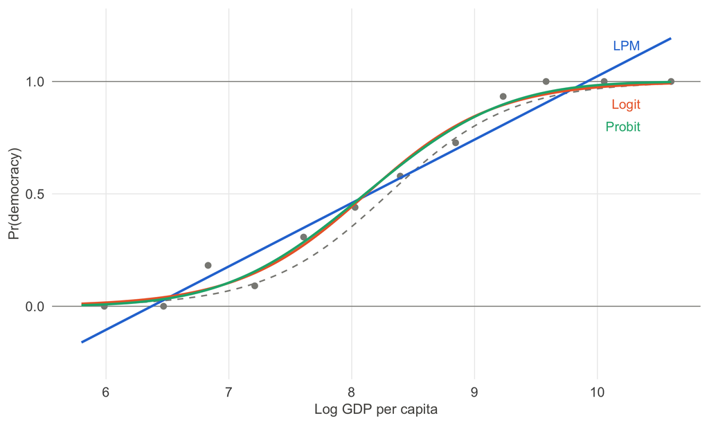

Fitted Pr(democracy) against log GDP per capita at oil = 0, three estimators, n = 205. Grey points are binned means; the dashed line is the true DGP.

# Part 1: two teams, four quantities

Same data, same fitted model. Each team computes two of the four quantities below, then writes both on the board: the number, and one sentence saying what it means, with units. Twelve minutes of work, two minutes to write.

**Team 1**

### Quantity 1: the linear probability model

Fit the LPM and report the coefficient on `oil`, with heteroskedasticity-robust standard errors (Lecture 7 slide 7 gives the reason).

```r
library(estimatr)
lpm <- lm_robust(y ~ oil + lgdp, data = countries)
```

On the board: *“Holding income constant, oil states are ___ percentage points less likely to be democracies.”*

### Quantity 2: the average case

Build one hypothetical country at the mean of `lgdp`. Predict its probability of democracy twice, once as an oil state and once not, and take the difference.

```r
avg <- data.frame(lgdp = mean(countries$lgdp))
p1  <- predict(logit, transform(avg, oil = 1), type = "response")
p0  <- predict(logit, transform(avg, oil = 0), type = "response")
p1 - p0
```

On the board: *“For the average country, being an oil state lowers the probability of democracy by ___ percentage points.”*

Before you sit down, say which of your two numbers you would put in a paper, and why.

**Team 2**

### Quantity 1: the odds ratio

Exponentiate the logit coefficient on `oil`.

```r
exp(coef(logit)["oil"])
```

On the board: *“Being an oil state multiplies the odds of democracy by ___.”*

### Quantity 2: the observed values

Do not build a hypothetical country. Take the 205 countries you have, set every one to `oil = 1` and predict; set every one to `oil = 0` and predict; average the 205 differences.

```r
d1 <- transform(countries, oil = 1)
d0 <- transform(countries, oil = 0)
mean(predict(logit, d1, type = "response") -
     predict(logit, d0, type = "response"))
```

On the board: *“Averaged across the countries in the sample, being an oil state lowers the probability of democracy by ___ percentage points.”*

Before you sit down, say which of your two numbers you would put in a paper, and why.

# Part 2: the board

Fill this in as the teams report.

| Team | Quantity | Number | Units |
| --- | --- | --- | --- |
| 1 | LPM coefficient on `oil` |  |  |
| 1 | Average case (MEM) |  |  |
| 2 | Odds ratio, `exp(beta_oil)` |  |  |
| 2 | Observed values (AME) |  |  |

Two questions to the room, in this order:

1. Which of these four answers the research question as it was stated?
2. Which of them are on a scale that lets you compare them with each other?

# Part 3: break your own answers

**Team 1**

### Where does the LPM go?

Your model can predict a probability. Find out whether it always predicts a *probability*.

```r
p_lpm <- fitted(lm(y ~ oil + lgdp, data = countries))
c(outside_01 = sum(p_lpm < 0 | p_lpm > 1), min = min(p_lpm), max = max(p_lpm))
```

Report to the room: under what conditions does this stop mattering?

### How average is the average case?

You built one country. Build four, and see how much the answer moves.

```r
at <- function(v) {
  a <- data.frame(lgdp = v)
  unname(predict(logit, transform(a, oil = 1), type = "response") -
         predict(logit, transform(a, oil = 0), type = "response"))
}
c(mean   = at(mean(countries$lgdp)),
  median = at(median(countries$lgdp)),
  q25    = at(quantile(countries$lgdp, 0.25)),
  q75    = at(quantile(countries$lgdp, 0.75)))
```

Then the harder version. Your recipe was “set every covariate to its mean”. Suppose the model also controlled for a binary `former_colony` with a sample mean of 0.62. What country is that?

Report to the room: what population does your number describe?

**Team 2**

### One odds ratio, many effects

Your odds ratio is a single number. Show the room how many changes in probability it is consistent with, by evaluating the same fitted model across the range of income.

```r
g <- expand.grid(lgdp = seq(5.8, 10.6, length.out = 200), oil = c(0, 1))
g$p <- predict(logit, g, type = "response")
w <- reshape(g, timevar = "oil", idvar = "lgdp", direction = "wide")
w$delta <- w$p.1 - w$p.0
```

Report to the room: is there a question for which the odds ratio is the right answer?

### Is the SE of an average the average of the SEs?

You averaged 205 numbers, each with its own uncertainty. Test the obvious guess.

```r
X   <- model.matrix(logit)
w_i <- fitted(logit) * (1 - fitted(logit))
V   <- solve(t(X) %*% diag(w_i) %*% X)       # Lecture 8, slide 7
```

Get a standard error on each country’s difference, and one on their average, and compare.

Report to the room: what would have to be true for the naive guess to hold?

# Part 4: uncertainty, three ways

Eight minutes. Both teams do the same three steps, each on one of their own quantities from Part 1. This is Lecture 8 applied to something the coefficient table does not print.

**One.** Rebuild the variance of $\hat\beta$ by hand, from slide 7, and check it against `summary()`.

```r
rbind(hand = sqrt(diag(V)), glm = summary(logit)$coefficients[, 2])
```

**Two.** Draw 2,000 values of $\tilde\beta$ from the sampling distribution on Lecture 8 slide 6, $\hat\beta \sim N(\hat\beta, [-H(\hat\beta)]^{-1})$.

```r
set.seed(1)
B <- MASS::mvrnorm(2000, coef(logit), V)
```

**Three.** Recompute your quantity on each of the 2,000 draws, and take the 2.5th and 97.5th percentiles.

# Exit ticket

One line, on a card, handed in before you leave:

> **What does `glm()`’s coefficient table tell you, and what does it not?**

# References

Arel-Bundock, V. (2026) *Model to Meaning: How to Interpret Statistical Models Using R*. CRC Press. https://marginaleffects.com

Hanmer, M. J. & Kalkan, K. O. (2013) “Behind the Curve: Clarifying the Best Approach to Calculating Predicted Probabilities and Marginal Effects from Limited Dependent Variable Models.” *American Journal of Political Science* 57(1): 263-277. doi:10.1111/j.1540-5907.2012.00602.x

King, G., Tomz, M. & Wittenberg, J. (2000) “Making the Most of Statistical Analyses: Improving Interpretation and Presentation.” *American Journal of Political Science* 44(2): 347-361. doi:10.2307/2669316

Mood, C. (2010) “Logistic Regression: Why We Cannot Do What We Think We Can Do, and What We Can Do About It.” *European Sociological Review* 26(1): 67-82. doi:10.1093/esr/jcp006

Rodríguez, G. *Generalized Linear Models*, Princeton lecture notes, 3.1-3.7. https://grodri.github.io/glms